# W4 STAT5003 RMD

Victor Z. Nygaard, vnyg7406

Last compiled on 28. januar, 2023

# 1

We load in the data:

```r
movielens <- read.csv("../Data/movielens_top40.csv", header = TRUE)
head(movielens)[,1:6]
```

```
##                           user_1 user_6 user_7 user_15 user_17 user_18
## Aladdin (1992)                NA      5    3.0       3      NA     3.5
## American Beauty (1999)         5     NA    4.0       4     4.0      NA
## Apollo 13 (1995)              NA      4    4.5      NA     3.5      NA
## Back to the Future (1985)      5     NA    5.0       5     4.5     4.0
## Batman (1989)                  4      3    3.0      NA     4.5      NA
## Braveheart (1995)              4      5     NA      NA     4.5     4.5
```

Some of the movienames are exceptionately long, we shorten some of the longest ones to get more legible dendrograms later:

```r
rownames(movielens) <- abbreviate(rownames(movielens), minlength=25)
```

We take a look at the `hclust` and subsequently the `dist` functions:

```r
#?hclust
#?dist
```

We apply `dist` to our data (using default $\ell_2$ distance):

```r
movie_dist <- movielens %>% dist()
```

We use `movie_dist` in `hclust` using various clustering methods:

```r
movie_clust_single <- movie_dist %>% hclust(method = "single")
movie_clust_average <- movie_dist %>% hclust(method = "average")
movie_clust_complete <- movie_dist %>% hclust(method = "complete")
```

We load in the `ggdendro` package to do dendrograms in a `ggplot`-like enviornment

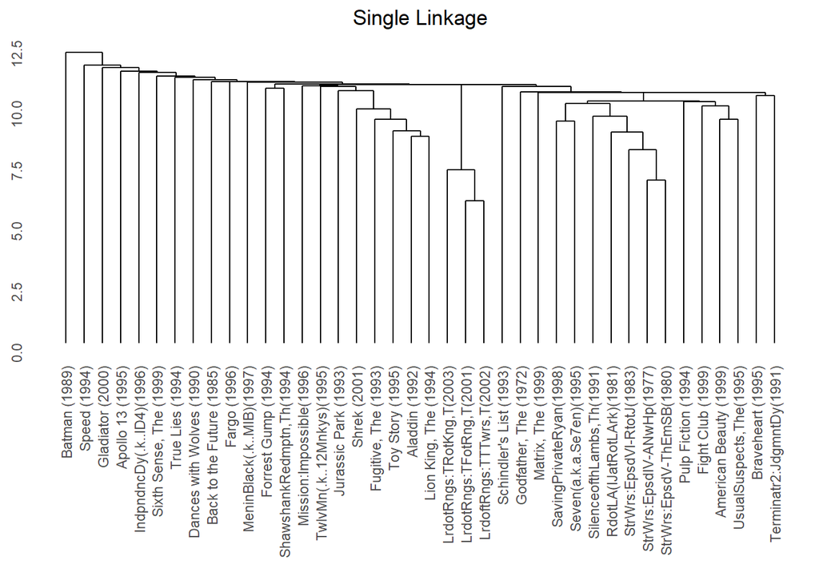

```r
library(ggdendro)
#?ggdendrogram
p_single <- movie_clust_single %>% ggdendrogram(rotate = FALSE) +
   labs(title = "Single Linkage") +
  theme(plot.title=element_text(hjust=0.5))
p_average <- movie_clust_average %>% ggdendrogram(rotate = F) +
   labs(title = "Average Linkage") +
   theme(plot.title=element_text(hjust=0.5))
p_complete <- movie_clust_complete %>% ggdendrogram(rotate = F) +
   labs(title = "Complete Linkage") +
   theme(plot.title=element_text(hjust=0.5))
p_single
```

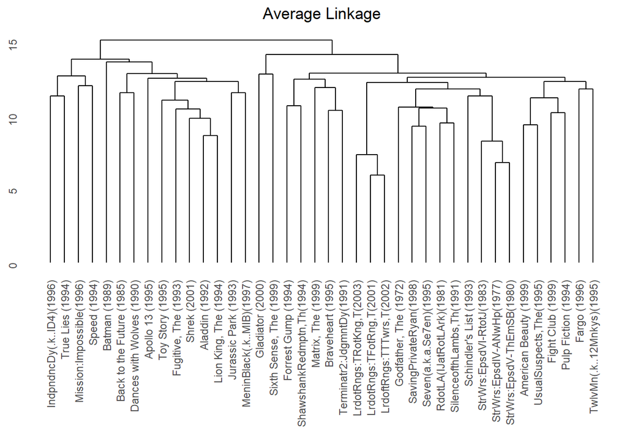

```r
p_average
```

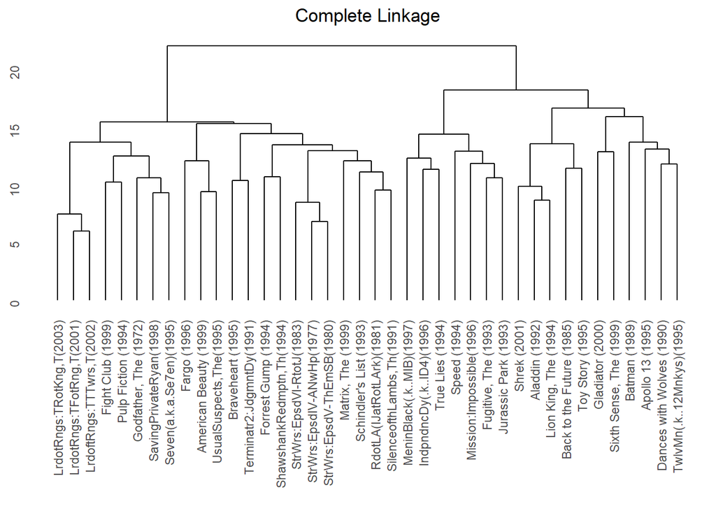

```r
p_complete
```

We cut off the seperation after four clusters for each of the clustering methods:

```r
n_clust <- 4
movie_clust_cut_single <- movie_clust_single %>% cutree(k = n_clust)
movie_clust_cut_average <- movie_clust_average %>% cutree(k = n_clust)
movie_clust_cut_complete <- movie_clust_complete %>% cutree(k = n_clust)
```

We are able to extract the movies in cluster $1$ using (beware of somewhat long output):

```r
mccs_df <- movie_clust_cut_single %>% as.data.frame()
mcca_df <- movie_clust_cut_average %>% as.data.frame()
mccc_df <- movie_clust_cut_complete %>% as.data.frame()
colnames(mccs_df) <- c("Cluster")
colnames(mcca_df) <- c("Cluster")
colnames(mccc_df) <- c("Cluster")

(mccs_df_C1 <- mccs_df %>% filter(Cluster == 1))
```

```
##                           Cluster
## Aladdin (1992)                  1
## American Beauty (1999)          1
## Apollo 13 (1995)                1
## Back to the Future (1985)       1
## Braveheart (1995)               1
## Dances with Wolves (1990)       1
## Fargo (1996)                    1
## Fight Club (1999)               1
## Forrest Gump (1994)             1
## Fugitive, The (1993)            1
## Godfather, The (1972)           1
## IndpndncDy(.k..ID4)(1996)       1
## Jurassic Park (1993)            1
## Lion King, The (1994)           1
## LrdotRngs:TFotRng,T(2001)       1
## LrdotRngs:TRotKng,T(2003)       1
## LrdoftRngs:TTTwrs,T(2002)       1
## Matrix, The (1999)              1
## MeninBlack(.k..MIB)(1997)       1
## Mission:Impossible(1996)        1
## Pulp Fiction (1994)             1
## RdotLA(IJatRotLArk)(1981)       1
## SavingPrivateRyan(1998)         1
## Schindler's List (1993)         1
## Seven(a.k.a.Se7en)(1995)        1
## ShawshankRedmptn,Th(1994)       1
## Shrek (2001)                    1
## SilenceofthLambs,Th(1991)       1
## Sixth Sense, The (1999)         1
## StrWrs:EpsdIV-ANwHp(1977)       1
## StrWrs:EpsdV-ThEmSB(1980)       1
## StrWrs:EpsdVI-RtotJ(1983)       1
## Terminatr2:JdgmntDy(1991)       1
## Toy Story (1995)                1
## True Lies (1994)                1
## TwlvMn(.k..12Mnkys)(1995)       1
## UsualSuspects,The(1995)         1
```

```r
(mcca_df_C1 <- mcca_df %>% filter(Cluster == 1))
```

```
##                           Cluster
## Aladdin (1992)                  1
## Apollo 13 (1995)                1
## Back to the Future (1985)       1
## Batman (1989)                   1
## Dances with Wolves (1990)       1
## Fugitive, The (1993)            1
## Jurassic Park (1993)            1
## Lion King, The (1994)           1
## MeninBlack(.k..MIB)(1997)       1
## Shrek (2001)                    1
## Toy Story (1995)                1
```

```r
(mccc_df_C1 <- mccc_df %>% filter(Cluster == 1))
```

```
##                           Cluster
## Aladdin (1992)                  1
## Back to the Future (1985)       1
## Lion King, The (1994)           1
## Shrek (2001)                    1
## Toy Story (1995)                1
```

We may collect the dataframes together using

```r
clusterings_df <- cbind(rbind(mccs_df, mcca_df, mccc_df), Method =
               c(rep("Single", nrow(mccs_df)),
                 rep("Average", nrow(mcca_df)),
                 rep("Complete", nrow(mccc_df))))
```

We may find the height at which to cut the tree to seperate into four clusters by for example looking at the dendrogramplots and counting at which point a horizontal line would intercept the dendrogram four times.

[figure not shown]

```r
p_single + geom_hline(yintercept=11.28, colour = "red", linetype = "dashed")
```

[figure not shown]

```r
p_average + geom_hline(yintercept=13.55, colour = "red", linetype = "dashed")
```

[figure not shown]

```r
p_complete + geom_hline(yintercept=16, colour = "red", linetype = "dashed")
```

We may investigate whether the clustering clusters based on missing values or by ranking. We may transform the data $0/1$ format, mapping `NA`’s to $0$ and numericals to $1$ by the following commands

```r
movielens01 <- movielens
#movielens01[movielens01 %>% is.na()] <- 0; movielens01[movielens01>0] <- 1
movielens01 <- !is.na(movielens)
```

We may calculate the new distance matrix using the $\ell_1$ norm:

```r
movie_dist01 <- movielens01 %>% dist(method = "manhattan")
```

We may recalculate the clusterings, cut them, and put them into dataframes

```r
movie_clust_single01 <- movie_dist01 %>% hclust(method = "single")
movie_clust_average01 <- movie_dist01 %>% hclust(method = "average")
movie_clust_complete01 <- movie_dist01 %>% hclust(method = "complete")

n_clust <- 4
movie_clust_cut_single01 <- movie_clust_single01 %>% cutree(k = n_clust)
movie_clust_cut_average01 <- movie_clust_average01 %>% cutree(k = n_clust)
movie_clust_cut_complete01 <- movie_clust_complete01 %>% cutree(k = n_clust)

mccs_df01 <- movie_clust_cut_single01 %>% as.data.frame()
mcca_df01 <- movie_clust_cut_average01 %>% as.data.frame()
mccc_df01 <- movie_clust_cut_complete01 %>% as.data.frame()

clusterings_df01 <- cbind(Cluster = rbind(mccs_df01, mcca_df01, mccc_df01), Method =
               c(rep("Single", nrow(mccs_df01)),
                 rep("Average", nrow(mcca_df01)),
                 rep("Complete", nrow(mccc_df01))))
colnames(clusterings_df01) <- c("Cluster", "Method") #For some reason had problems getting 'cluster' colname to stick with cbind
head(clusterings_df01)
```

```
##                           Cluster Method
## Aladdin (1992)                  1 Single
## American Beauty (1999)          2 Single
## Apollo 13 (1995)                3 Single
## Back to the Future (1985)       2 Single
## Batman (1989)                   2 Single
## Braveheart (1995)               2 Single
```

Finally we could compare the clusterings by analysing the following `comparison_df` dataframe

```r
comparison_df <- inner_join(rownames_to_column(clusterings_df), rownames_to_column(clusterings_df01), by = c("rowname" = "rowname", "Method" = "Method"), suffix = c("_NA", "_01"))
head(comparison_df)
```

```
##                     rowname Cluster_NA Method Cluster_01
## 1            Aladdin (1992)          1 Single          1
## 2    American Beauty (1999)          1 Single          2
## 3          Apollo 13 (1995)          1 Single          3
## 4 Back to the Future (1985)          1 Single          2
## 5             Batman (1989)          2 Single          2
## 6         Braveheart (1995)          1 Single          2
```

```r
comparison_df %>% count(Cluster_NA == Cluster_01)
```

```
##   Cluster_NA == Cluster_01  n
## 1                    FALSE 72
## 2                     TRUE 48
```

```r
count(comparison_df, Cluster_NA == Cluster_01)
```

```
##   Cluster_NA == Cluster_01  n
## 1                    FALSE 72
## 2                     TRUE 48
```

We thus see that in 72 cases, the different classification approaches disagree, while in the remaining $120-72=48$ cases, the classification agrees. Thus approaches yield different results, and we can conclude that `hclust` does care about more than solely whether or not the values are `NA` for $4$ clusters.

Another approach would be to explore $k$-means methods. Regarding this, we make the new dataset, mapping `NA`’s to zero, but keeping the magnitude of the ratings:

```r
movielensNA0 <- movielens; movielensNA0[movielensNA0 %>% is.na()] <- 0
head(movielensNA0)[,1:6]
```

```
##                           user_1 user_6 user_7 user_15 user_17 user_18
## Aladdin (1992)                 0      5    3.0       3     0.0     3.5
## American Beauty (1999)         5      0    4.0       4     4.0     0.0
## Apollo 13 (1995)               0      4    4.5       0     3.5     0.0
## Back to the Future (1985)      5      0    5.0       5     4.5     4.0
## Batman (1989)                  4      3    3.0       0     4.5     0.0
## Braveheart (1995)              4      5    0.0       0     4.5     4.5
```

We may cluster the movies into $4$ clusters:

```r
n_km_clust <- 4
movie_km <- kmeans(movielensNA0, centers = n_km_clust)
```

We may take a look at the resulting object using `str`

```r
str(movie_km)
```

```
## List of 9
##  $ cluster     : Named int [1:40] 1 3 1 4 1 2 2 3 3 3 ...
##   ..- attr(*, "names")= chr [1:40] "Aladdin (1992)" "American Beauty (1999)" "Apollo 13 (1995)" "Back to the Future (1985)" ...
##  $ centers     : num [1:4, 1:153] 1.69 4.33 2.78 4.83 3.69 ...
##   ..- attr(*, "dimnames")=List of 2
##   .. ..$ : chr [1:4] "1" "2" "3" "4"
##   .. ..$ : chr [1:153] "user_1" "user_6" "user_7" "user_15" ...
##  $ totss       : num 21117
##  $ withinss    : num [1:4] 5147 1059 8435 1573
##  $ tot.withinss: num 16214
##  $ betweenss   : num 4903
##  $ size        : int [1:4] 13 3 18 6
##  $ iter        : int 2
##  $ ifault      : int 0
##  - attr(*, "class")= chr "kmeans"
```

We extract the `size` attribute:

```r
movie_km$size
```

```
## [1] 13  3 18  6
```

Thus the algorithm has placed $13, 3, 18, 6$ movies in clusters $1,2,3,4$ respectively.

We might do PCA on the k-means:

```r
movie_pca <- prcomp(movielensNA0, scale = TRUE)
str(movie_pca)
```

```
## List of 5
##  $ sdev    : num [1:40] 4.92 3.75 3.51 2.89 2.71 ...
##  $ rotation: num [1:153, 1:40] 0.0578 -0.1184 0.0203 0.1222 0.1246 ...
##   ..- attr(*, "dimnames")=List of 2
##   .. ..$ : chr [1:153] "user_1" "user_6" "user_7" "user_15" ...
##   .. ..$ : chr [1:40] "PC1" "PC2" "PC3" "PC4" ...
##  $ center  : Named num [1:153] 2.85 2.12 2.34 2.49 3.3 ...
##   ..- attr(*, "names")= chr [1:153] "user_1" "user_6" "user_7" "user_15" ...
##  $ scale   : Named num [1:153] 2.2 2.21 2.15 2.07 2.08 ...
##   ..- attr(*, "names")= chr [1:153] "user_1" "user_6" "user_7" "user_15" ...
##  $ x       : num [1:40, 1:40] -6.258 3.759 -7.778 0.583 -5.853 ...
##   ..- attr(*, "dimnames")=List of 2
##   .. ..$ : chr [1:40] "Aladdin (1992)" "American Beauty (1999)" "Apollo 13 (1995)" "Back to the Future (1985)" ...
##   .. ..$ : chr [1:40] "PC1" "PC2" "PC3" "PC4" ...
##  - attr(*, "class")= chr "prcomp"
```

```r
movie_km_pca_df <- data.frame(movie_pca$x, movie_km$cluster)
head(movie_km_pca_df)[,c(1,2,ncol(movie_km_pca_df))]
```

```
##                                 PC1         PC2 movie_km.cluster
## Aladdin (1992)            -6.258317 -3.84949107                1
## American Beauty (1999)     3.758609  3.02051582                3
## Apollo 13 (1995)          -7.778490 -0.06864757                1
## Back to the Future (1985)  0.583437  0.02148041                4
## Batman (1989)             -5.853029  2.01613370                1
## Braveheart (1995)         -1.154110  2.64831518                2
```

Calculate the “Variance explained” for the two first principle components

```r
PCVarEx <- as.numeric(movie_pca$sdev^2)[1:2]/sum(as.numeric(movie_pca$sdev^2))
```

And subsequently plot the PCA plot:

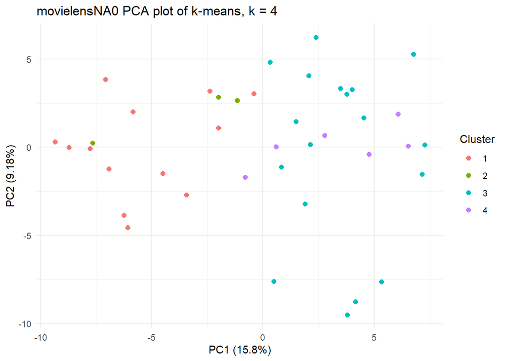

```r
ggplot(movie_km_pca_df,
       aes(x = PC1, y = PC2, colour = as.factor(movie_km.cluster))) +
   geom_point(size = 2) +  labs(colour = 'Cluster',
                               x = paste0("PC1 (", signif(PCVarEx[1],3)*100, "%)"),
                               y = paste0("PC2 (", signif(PCVarEx[2],3)*100, "%)"),
                               title = paste0("movielensNA0 PCA plot of k-means, k = ",                                 n_km_clust))
```

We may calculate k-means for $k$ from $2$ to $6$ and compare the internal and external cluster distances resulting therefrom.

```r
kvals <- 2:6
movie_km_2t6 <- lapply(kvals, function(k){
    kmeans(movielensNA0, centers = k)
})

movie_km_2t6var_df <- melt(data.frame(Within = sapply(kvals-1, function(x) {
   movie_km_2t6[[x]]$tot.withinss}), Between = sapply(kvals-1, function(x) {
   movie_km_2t6[[x]]$betweenss}), k = kvals), id.vars = "k")
movie_km_2t6var_df
```

```
##    k variable     value
## 1  2   Within 18424.533
## 2  3   Within 16885.217
## 3  4   Within 15446.353
## 4  5   Within 14694.069
## 5  6   Within 13697.004
## 6  2  Between  2692.304
## 7  3  Between  4231.621
## 8  4  Between  5670.485
## 9  5  Between  6422.769
## 10 6  Between  7419.834
```

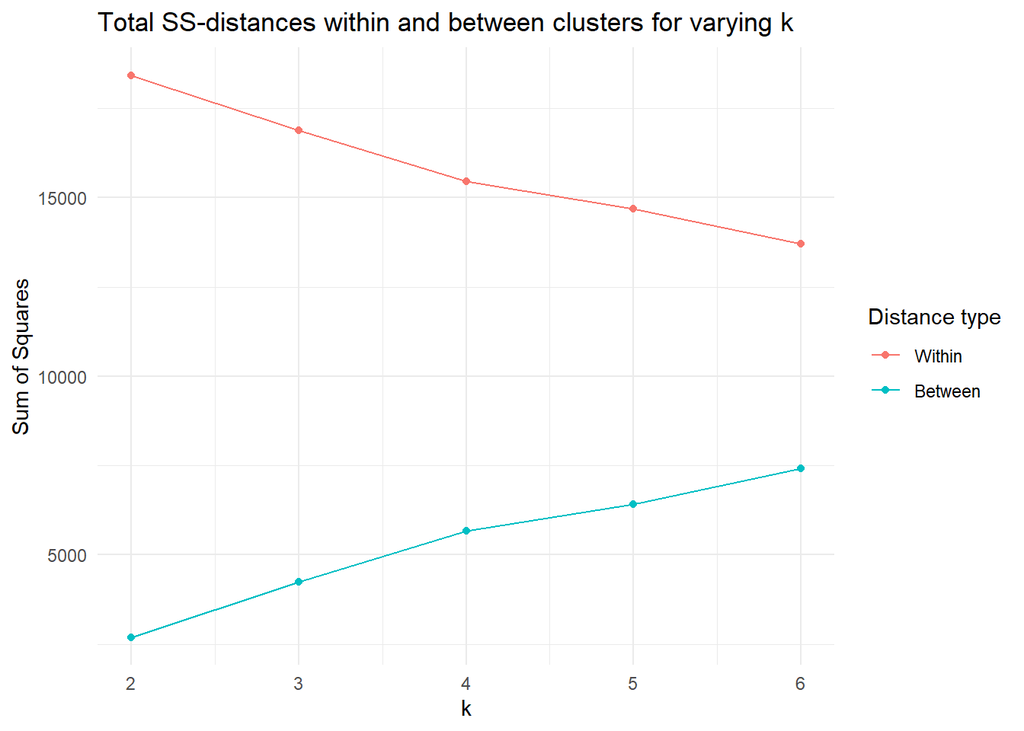

```r
ggplot(movie_km_2t6var_df, aes(x = k, y = value, colour = variable)) + geom_point() + geom_line() + labs(title = paste0("Total SS-distances within and between clusters for varying k"), y = "Sum of Squares", colour = 'Distance type')
```

#2 We may load in the data:

```r
author.dat <- read.csv("../Data/author_count.csv", header = TRUE)
numeric.dat <- author.dat[-1]
authors <- factor(author.dat[[1]])
head(author.dat)[,1:6]
```

```
##   author  a all also an and
## 1 Austen 46  12    0  3  66
## 2 Austen 35  10    0  7  44
## 3 Austen 46   2    0  3  40
## 4 Austen 40   7    0  4  64
## 5 Austen 29   5    0  6  52
## 6 Austen 27   8    0  3  42
```

And calculate the PCA, incorporating scaling and centering:

```r
word_pca <- prcomp(numeric.dat, scale = T, center = T)
word_pca_wlabel <- data.frame(word_pca$x, authors)
#head(word_pca_wlabel)[,1:6]
word_pcVarEx <- as.numeric(word_pca$sdev^2)[1:2]/sum(as.numeric(word_pca$sdev^2))
```

and plot the first two principle components, also calculating the proportion of variance of each component:

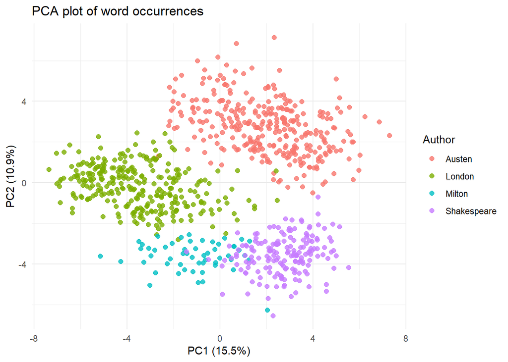

```r
(word_pca_p <- ggplot(word_pca_wlabel,
       aes(x = PC1, y = PC2, colour = as.factor(word_pca_wlabel$authors))) +
   geom_point(size = 2, alpha = 0.8) +  labs(colour = 'Author',
                               x = paste0("PC1 (", signif(word_pcVarEx[1],3)*100, "%)"),
                               y = paste0("PC2 (", signif(word_pcVarEx[2],3)*100, "%)"),
                               title = paste0("PCA plot of word occurrences")))
```

We note that while Austen and London seem to have rather good seperation, $2$ dimensional PCA has not been able to seperate out all of the Milton data from the Shakespeare.

We may attempt to provide a better visualisation of the seperation using tSNE.

```r
#install.packages("Rtsne")
library(Rtsne)
```

Looking into `Rtsne` we see quite a number of parameters that are possible to tune. We are choosing only to tune the `perplexity` and leaving everything else as-is. In choosing which perplexity levels are worth investigating, we try levels of multiples of $5$ from $5$ up to the number of features $69,$ and add $1$ to get $14$ plots in total.

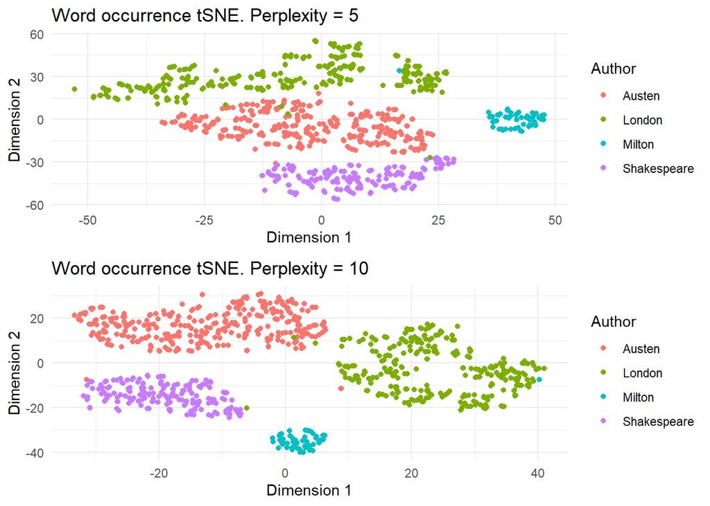

```r
#?Rtsne #checking doc
perPlexVals <- seq(5,dim(numeric.dat)[2]+1,5)
tsne_df_list <- lapply(perPlexVals, function(p) {
    data.frame(dim = Rtsne(numeric.dat, perplexity = p, max_iter = 1000)[['Y']], labels = authors)})
# why does which(p == ...) not work?
plots <- lapply(perPlexVals, function(p) {
   ggplot(tsne_df_list[[p/5]], aes(dim.1, dim.2, colour = labels)) + geom_point() + ggtitle(paste0("Word occurrence tSNE. Perplexity = ", p)) + labs(x = "Dimension 1", y  = "Dimension 2", colour = 'Author')
})
#do.call("grid.arrange", c(plots, ncol = 2))
# for (i in seq(1,13,2)) {
#    grid.arrange(plots[[i]], plots[[i+1]], ncol = 2)
# }
grid.arrange(plots[[1]], plots[[2]], ncol = 1)
```

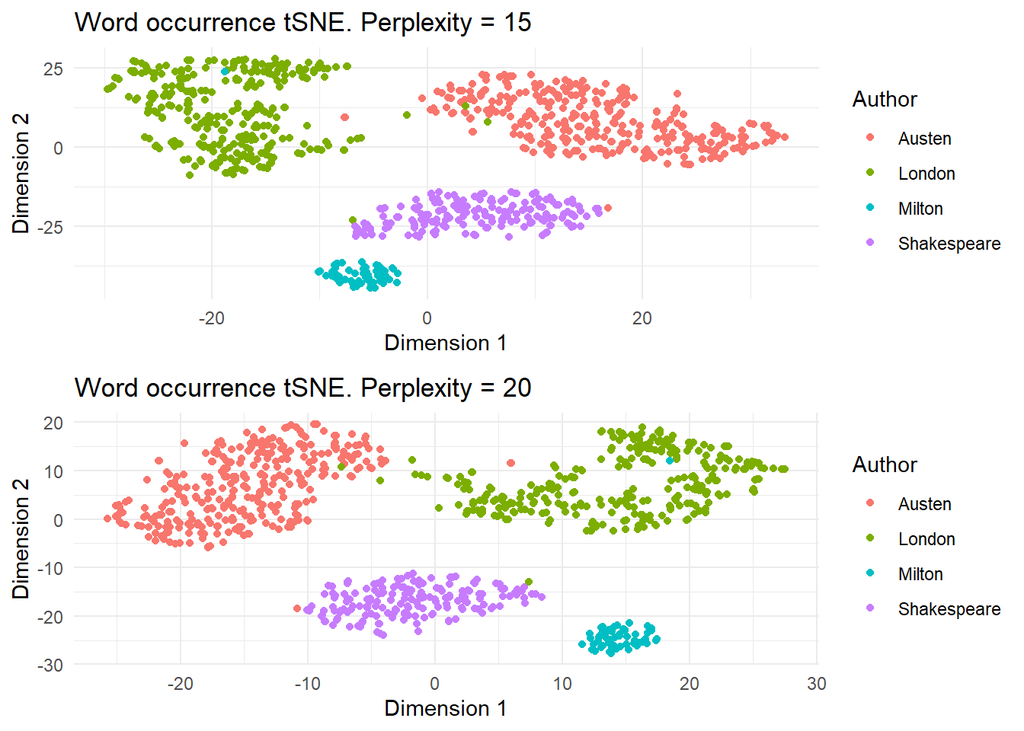

```r
grid.arrange(plots[[3]], plots[[4]], ncol = 1)
```

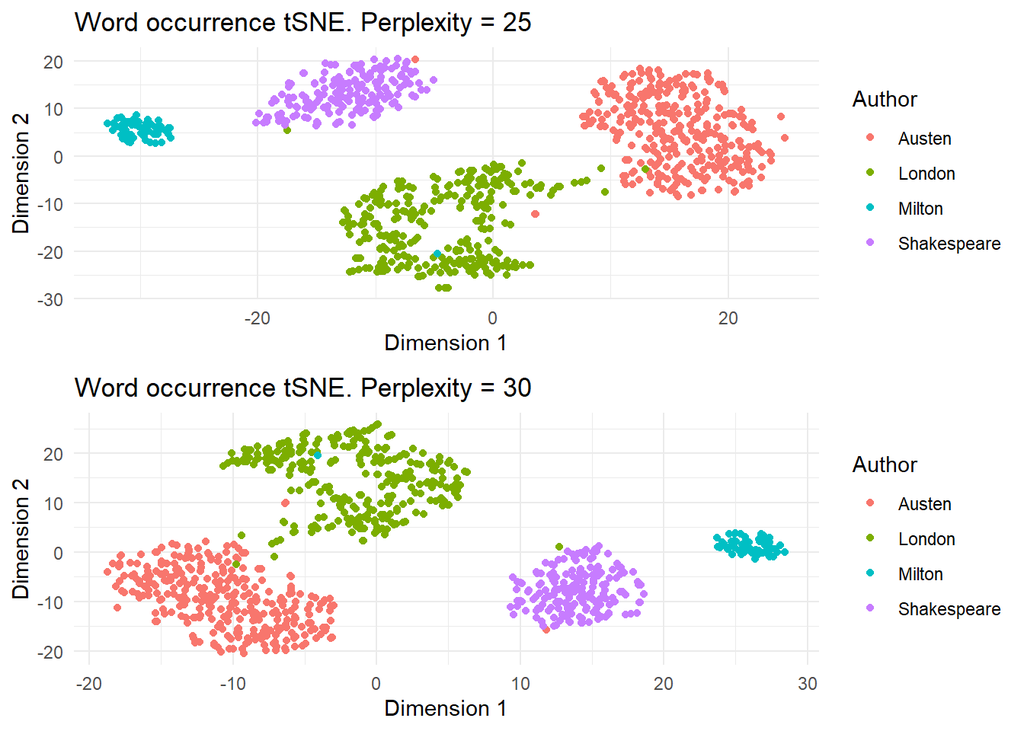

```r
grid.arrange(plots[[5]], plots[[6]], ncol = 1)
```

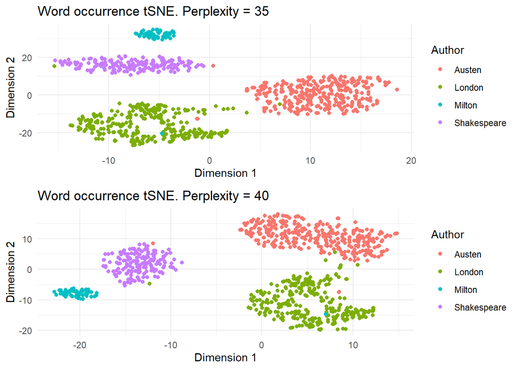

```r
grid.arrange(plots[[7]], plots[[8]], ncol = 1)
```

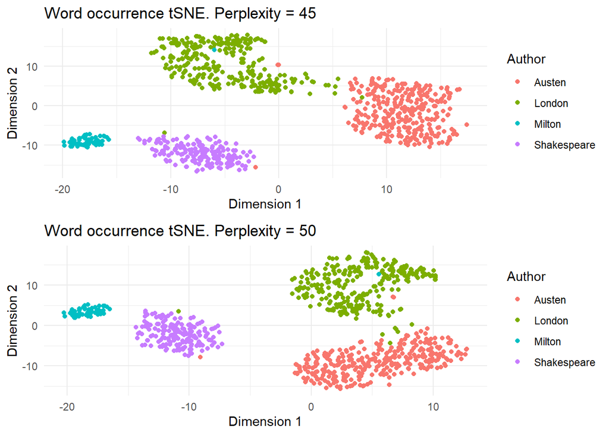

```r
grid.arrange(plots[[9]], plots[[10]], ncol = 1)
```

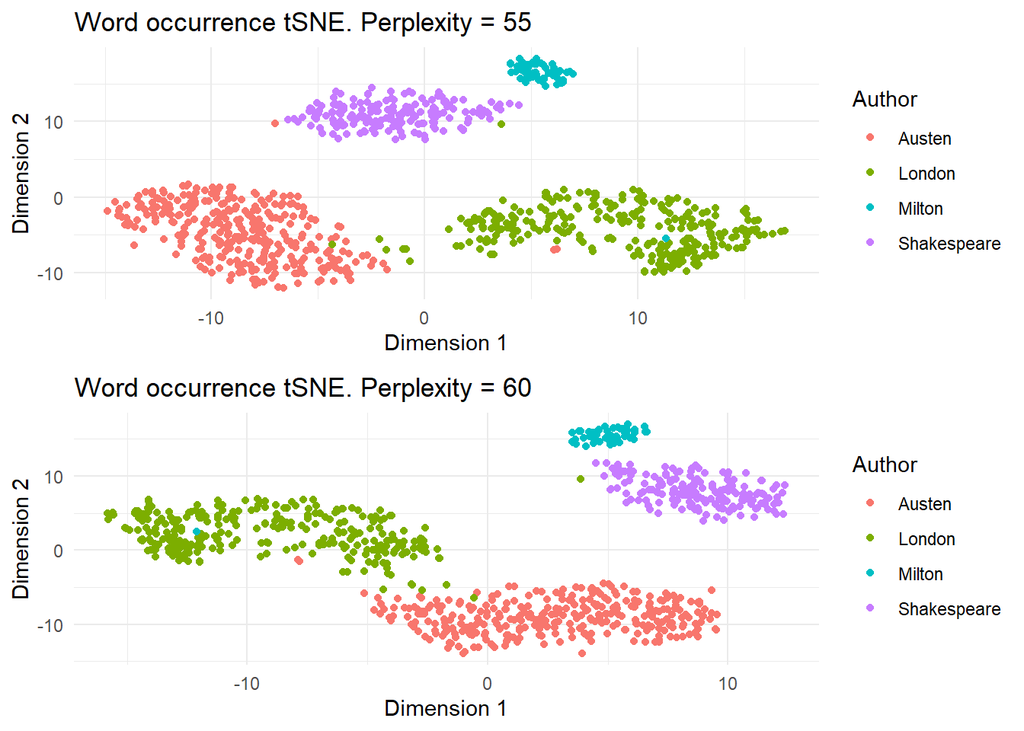

```r
grid.arrange(plots[[11]], plots[[12]], ncol = 1)
```

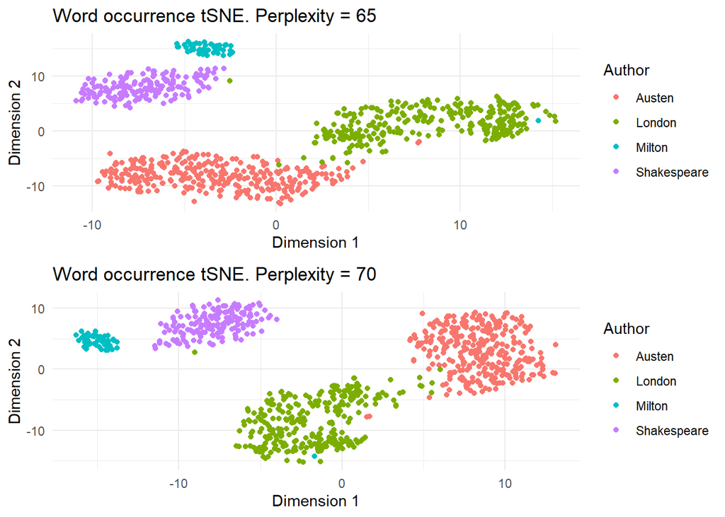

```r
grid.arrange(plots[[13]], plots[[14]], ncol = 1)
```

As all perplexity levels do a very good job at isolating the clusters of the authors (noting that we have employed a default random seed of $314$), we may also try with perplexity $=3$ to see if there is a difference:

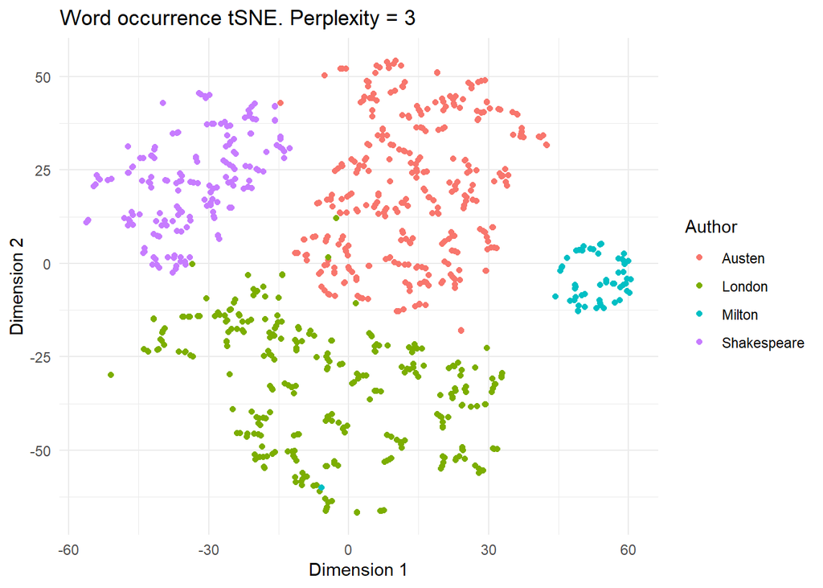

```r
data.frame(dim = Rtsne(numeric.dat, perplexity = 3, max_iter = 1000)[['Y']], labels = authors) %>% ggplot(aes(dim.1, dim.2, colour = labels)) + geom_point() + ggtitle(paste0("Word occurrence tSNE. Perplexity = ", 3)) + labs(x = "Dimension 1", y = "Dimension 2", colour = 'Author')
```

The tSNE for this lower perplexity value is once again very good at isolating the points, it does however become more evident how the lower perplexity is tuning SNE to prefer local clusterings.

We may also try to plot the data using MDS. In aid of this, we calculate MDS based on the metrics of the Euclidean, the maximum and the Manhattan. We will use the default `cmdscale` $k$ of $2$ as we want to do $2D$ plots.

```r
mds_euc <- data.frame(dim = cmdscale(dist(numeric.dat, method = "euclidean")), author = authors)

mds_max <- data.frame(dim = cmdscale(dist(numeric.dat, method = "maximum")), author = authors)

mds_man <- data.frame(dim = cmdscale(dist(numeric.dat, method = "manhattan")), author = authors)
```

We may plot the three results:

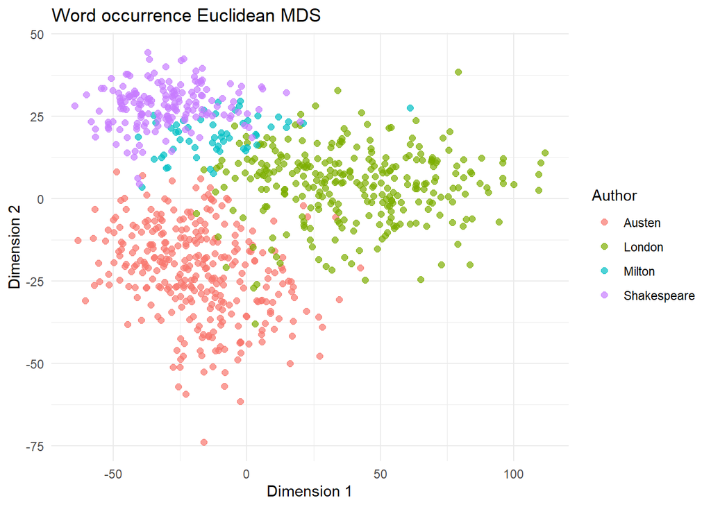

```r
mds_euc %>% ggplot(aes(dim.1, dim.2, colour = author)) +
   geom_point(size = 2, alpha = 0.7) + labs(x = "Dimension 1",
                               y = "Dimension 2",
                               colour = 'Author',
                               title = "Word occurrence Euclidean MDS")
```

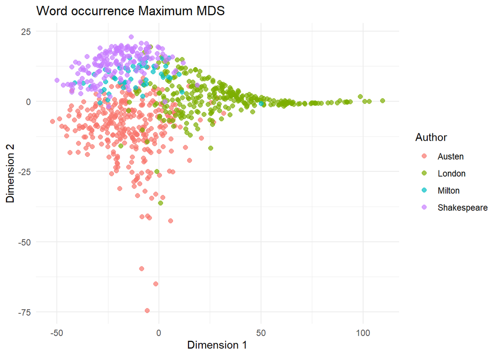

```r
mds_max %>% ggplot(aes(dim.1, dim.2, colour = author)) +
   geom_point(size = 2, alpha = 0.7) + labs(x = "Dimension 1",
                               y = "Dimension 2",
                               colour = 'Author',
                               title = "Word occurrence Maximum MDS")
```

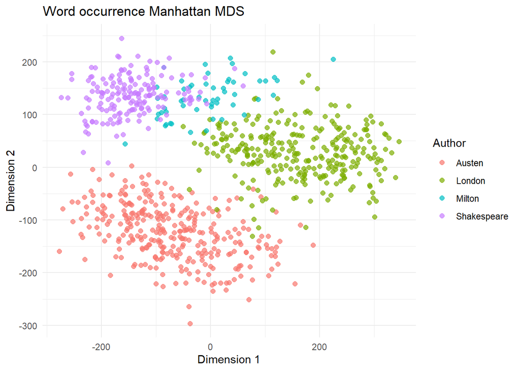

```r
(mds_man_p <- mds_man %>% ggplot(aes(dim.1, dim.2, colour = author)) +
   geom_point(size = 2, alpha = 0.7) + labs(x = "Dimension 1",
                               y = "Dimension 2",
                               colour = 'Author',
                               title = "Word occurrence Manhattan MDS"))
```

We see that while the Euclidean and Manhattan distances do a reasonable job at separating the points, MDS struggles to separate out the authors based on the maximum norm.

Comparing the different methods, we may assess a best implementation of each and compare these. Having only one implementation of PCA we pick that one. With all the tSNE plots being rather good at splitting the works of the four authors apart, we choose to work based on perplexity $=10.$ While not perfect, we assess that the $\ell_1$ MDS does the best job of separating the works of the authors. We may replot the three plots to remind ourselves of them:

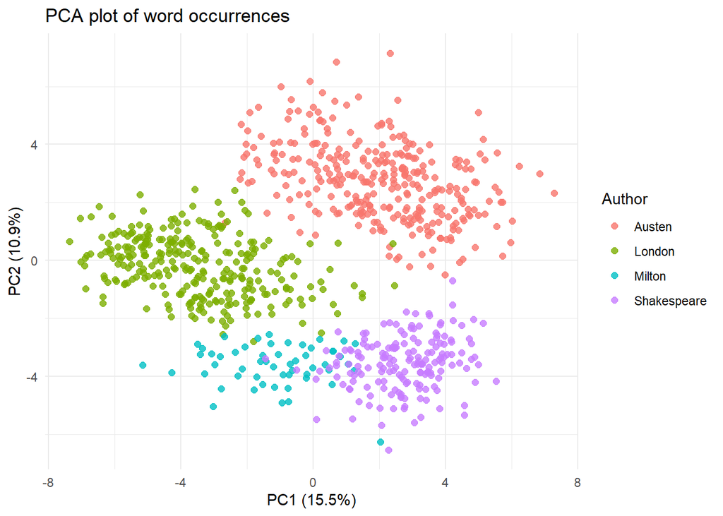

```r
word_pca_p
```

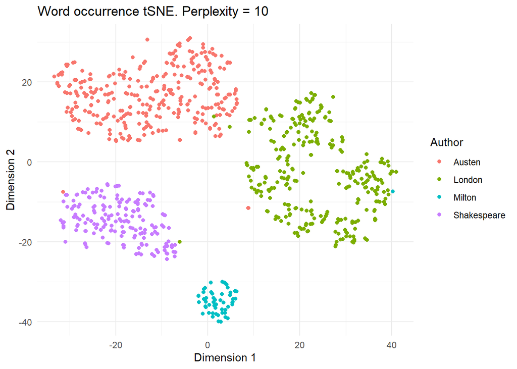

```r
plots[[2]]
```

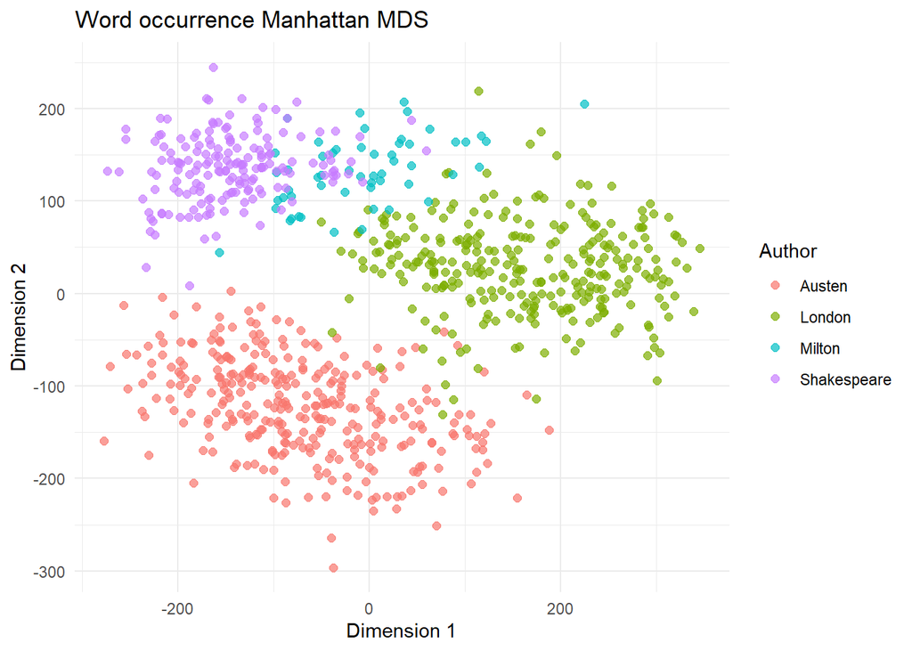

```r
mds_man_p
```

We see from the plots, that while tSNE does an excellent job seperating out the author clusters with only a very small number of outliers, the Manhattan MDS and PCA seem to have the same struggle of separating out the word-frequency of use of Milton’s works, from those of Shakespeare, with the Manhattan-based MDS also having some overlap between London and Milton.